# FinalProject

Has the World Gotten Happier Over the Years Recently?

Sean Kim

Introduction

Considering everything that has occurred in the most recent years, it might seem like a somewhat grim and unforgiving time in the world. With a worldwide pandemic going on for already almost 3 years, and more recent developments in Ukraine, many would think that the world has seen better days. However, is it really true that the world is getting darker and gloomier with each passing year? Every year, the United Nations Sustainable Development Solutions Network delivers the World Happiness Report, a collection of articles and rankings of national happiness as a whole based on responses from polling. It uses a variety of quality of life factors, in addition to polled responses, to quantify happiness around the world. While it could be argued that happiness is difficult to quantify, if we want to know if the world truly is more or less happy than it was some years ago, then it is necessary to do so.

The datasets were obtained from Kaggle.com(link: https://www.kaggle.com/datasets/mathurinache/world-happiness-report). Its columns include country, happiness ranking, a happiness score from 1 to 10, GDP per capita, average family size, and standardized measures of freedom to make life choices, government trust by perceptions of corruption, generosity, and dystopia residual. In this tutorial, I will primarily be focusing on the relationship between happiness score and year, as the main focus is to see if happiness has increased over time or not, and testing it against my own hypothesis, which, as an optimist, is that the world has gotten happier in general over time. To do this, I will use Python 3 and its libraries pandas, numpy, scikit-learn, and matplotlib to manage the data and calculate the necessary statistics to find the trend of happiness over time.

Pandas: https://pandas.pydata.org/ Numpy: https://numpy.org/doc/stable/reference/index.html#reference Scikit-Learn: https://scikit-learn.org/stable/ Matplotlib: https://matplotlib.org/

Part 1: Data Collection/Curation and Part 2: Data Management/Representation

First, the important libraries must be imported and the dataset read in using pandas.read_csv, as the dataset comes in the form of several CSV(Comma Separated Value) files. Then, they must all be put together into one data table for ease of analysis using pandas' concat() method, and I also added a year column to all of them to note which year the data was collected from. For this analysis, I decided to exclude 2022 as it had data formatted with commas as decimal points instead of periods, and I want to look more at happiness historically rather than at a more recent time.

```python
import pandas as pd
import numpy as np
import matplotlib.pyplot as plt
import sklearn.model_selection as ms
import sklearn.metrics as met
from sklearn.linear_model import LinearRegression
import warnings
warnings.filterwarnings('ignore')
data1 = pd.read_csv("2015.csv", sep = ',')
data1['year'] = 2015
data2 = pd.read_csv("2016.csv", sep = ',')
data2['year'] = 2016
data3 = pd.read_csv("2017.csv", sep = ',')
data3['year'] = 2017
data4 = pd.read_csv("2018.csv", sep = ',')
data4['year'] = 2018
data5 = pd.read_csv("2019.csv", sep = ',')
data5['year'] = 2019
data6 = pd.read_csv("2020.csv", sep = ',')
data6['year'] = 2020
data7 = pd.read_csv("2021.csv", sep = ',')
data7['year'] = 2021
datalist = [data1, data2, data3, data4, data5, data6, data7]
data = pd.concat(datalist)
data
```

|  | Country | Region | Happiness Rank | Happiness Score | Standard Error | Economy (GDP per Capita) | Family | Health (Life Expectancy) | Freedom | Trust (Government Corruption) | ... | lowerwhisker | Logged GDP per capita | Ladder score in Dystopia | Explained by: Log GDP per capita | Explained by: Social support | Explained by: Healthy life expectancy | Explained by: Freedom to make life choices | Explained by: Generosity | Explained by: Perceptions of corruption | Dystopia + residual |
| --- | --- | --- | --- | --- | --- | --- | --- | --- | --- | --- | --- | --- | --- | --- | --- | --- | --- | --- | --- | --- | --- |
| 0 | Switzerland | Western Europe | 1.0 | 7.587 | 0.03411 | 1.39651 | 1.34951 | 0.94143 | 0.66557 | 0.41978 | ... | NaN | NaN | NaN | NaN | NaN | NaN | NaN | NaN | NaN | NaN |
| 1 | Iceland | Western Europe | 2.0 | 7.561 | 0.04884 | 1.30232 | 1.40223 | 0.94784 | 0.62877 | 0.14145 | ... | NaN | NaN | NaN | NaN | NaN | NaN | NaN | NaN | NaN | NaN |
| 2 | Denmark | Western Europe | 3.0 | 7.527 | 0.03328 | 1.32548 | 1.36058 | 0.87464 | 0.64938 | 0.48357 | ... | NaN | NaN | NaN | NaN | NaN | NaN | NaN | NaN | NaN | NaN |
| 3 | Norway | Western Europe | 4.0 | 7.522 | 0.03880 | 1.45900 | 1.33095 | 0.88521 | 0.66973 | 0.36503 | ... | NaN | NaN | NaN | NaN | NaN | NaN | NaN | NaN | NaN | NaN |
| 4 | Canada | North America | 5.0 | 7.427 | 0.03553 | 1.32629 | 1.32261 | 0.90563 | 0.63297 | 0.32957 | ... | NaN | NaN | NaN | NaN | NaN | NaN | NaN | NaN | NaN | NaN |
| ... | ... | ... | ... | ... | ... | ... | ... | ... | ... | ... | ... | ... | ... | ... | ... | ... | ... | ... | ... | ... | ... |
| 144 | NaN | NaN | NaN | NaN | NaN | NaN | NaN | NaN | NaN | NaN | ... | 3.276 | 7.926 | 2.43 | 0.451 | 0.731 | 0.007 | 0.405 | 0.103 | 0.015 | 1.800 |
| 145 | NaN | NaN | NaN | NaN | NaN | NaN | NaN | NaN | NaN | NaN | ... | 3.322 | 9.782 | 2.43 | 1.099 | 0.724 | 0.340 | 0.539 | 0.027 | 0.088 | 0.648 |
| 146 | NaN | NaN | NaN | NaN | NaN | NaN | NaN | NaN | NaN | NaN | ... | 3.282 | 7.676 | 2.43 | 0.364 | 0.202 | 0.407 | 0.627 | 0.227 | 0.493 | 1.095 |
| 147 | NaN | NaN | NaN | NaN | NaN | NaN | NaN | NaN | NaN | NaN | ... | 3.030 | 7.943 | 2.43 | 0.457 | 0.649 | 0.243 | 0.359 | 0.157 | 0.075 | 1.205 |
| 148 | NaN | NaN | NaN | NaN | NaN | NaN | NaN | NaN | NaN | NaN | ... | 2.449 | 7.695 | 2.43 | 0.370 | 0.000 | 0.126 | 0.000 | 0.122 | 0.010 | 1.895 |

1084 rows × 46 columns

Since the data for each dataset had different names for each of the same columns, I also had to combine columns together to create a dataset without multiple names for each parameter. For example, in the 2015 dataset happiness score was called Happiness Score, but 2018's was just called Score. There were also some columns with data about rankings, dystopia residual, standard error, region, whisker-highs, and whisker-lows, but I did not need them for the analysis I planned, so I dropped those columns. In addition, family, generosity, and social support were not defined for all years, so I also dropped those. Finally, I also dropped country, since I wasn't testing any hypotheses about country-specific information on happiness.

```python
score = ['Happiness Score', 'Happiness.Score', 'Score', 'Ladder score']
rank = ['Happiness Rank', 'Happiness.Rank', 'Overall rank']
region = ['Region', 'Regional indicator']
country = ['Country', 'Country or region', 'Country name']
error = ['Standard Error', 'Standard error of ladder score']
economy = ['Economy (GDP per Capita)', 'Economy..GDP.per.Capita.', 'GDP per capita', 'Logged GDP per capita']
family = ['Family']
supp = ['Social support']
dyst = ['Dystopia Residual', 'Dystopia.Residual', 'Ladder score in Dystopia', 'Dystopia + residual']
unused = ['Explained by: Log GDP per capita', 'Explained by: Social support', 'Explained by: Freedom to make life choices', 'Explained by: Generosity', 'Explained by: Perceptions of corruption', 'Explained by: Healthy life expectancy']
whiskers_and_conf = ['Whisker.high', 'Whisker.low', 'Lower Confidence Interval', 'Upper Confidence Interval', 'upperwhisker', 'lowerwhisker']
health = ['Health (Life Expectancy)', 'Health..Life.Expectancy.', 'Healthy life expectancy']
freedom = ['Freedom', 'Freedom to make life choices']
trust = ['Trust (Government Corruption)', 'Trust..Government.Corruption.', 'Perceptions of corruption']
generosity = ['Generosity']
data = data.drop(rank, 1)
data = data.drop(region, 1)
data = data.drop(country, 1)
data = data.drop(error, 1)
data = data.drop(family, 1)
data = data.drop(supp, 1)
data = data.drop(dyst, 1)
data = data.drop(unused, 1)
data = data.drop(whiskers_and_conf, 1)
data = data.drop(generosity, 1)
data['score'] = data[score].sum(1)
data['economy(GDP per capita)'] = data[economy].sum(1)
data['healthy life expectancy'] = data[health].sum(1)
data['freedom of life choices'] = data[freedom].sum(1)
data['perceptions of corruption'] = data[trust].sum(1)
data = data.drop(score, 1)
data = data.drop(economy, 1)
data = data.drop(health, 1)
data = data.drop(freedom, 1)
data = data.drop(trust, 1)
data.head()
```

|  | year | score | economy(GDP per capita) | healthy life expectancy | freedom of life choices | perceptions of corruption |
| --- | --- | --- | --- | --- | --- | --- |
| 0 | 2015 | 7.587 | 1.39651 | 0.94143 | 0.66557 | 0.41978 |
| 1 | 2015 | 7.561 | 1.30232 | 0.94784 | 0.62877 | 0.14145 |
| 2 | 2015 | 7.527 | 1.32548 | 0.87464 | 0.64938 | 0.48357 |
| 3 | 2015 | 7.522 | 1.45900 | 0.88521 | 0.66973 | 0.36503 |
| 4 | 2015 | 7.427 | 1.32629 | 0.90563 | 0.63297 | 0.32957 |

Now that all of the quantitative data that I wanted is properly obtained and organized, I can move on to the next step of the process.

Part 3: Exploratory Data Analysis

As an initial look into the general trend of how happiness changes over time, we can start with a scatterplot of happiness score against year, using pandas's plot method.

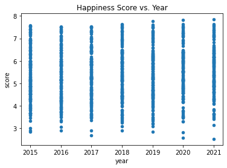

```python
plot1 = data.plot.scatter(x = 'year', y = 'score', title = 'Happiness Score vs. Year')
```

Looking at the plot, it doesn't seem like there is any obvious relationship between happiness and time just yet. To make a relationship more clear, a violin plot can be used, using matplotlib's violinplot method.

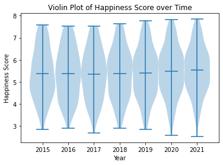

```python
fig, ax = plt.subplots()
years = [2015, 2016, 2017, 2018, 2019, 2020, 2021]
happinesslist = []
for y in years:
    scores = data.loc[data['year'] == y, ['score']]
    scores1 = scores.squeeze()
    scores2 = scores1.array
    happinesslist.append(scores2)
ax.violinplot(happinesslist, years, widths = 1, showmeans = True)
ax.set_xlabel("Year")
ax.set_ylabel("Happiness Score")
ax.set_title("Violin Plot of Happiness Score over Time")
```

While the violin plot shows that average happiness scores do not appear to have changed significantly over time, an interesting observation is that each of the years appear to have a relatively normal distribution of scores. In addition, as years go by, the skew of said distributions do appear to be going in the upwards direction, potentially indicating that scores are actually increasing after all. Next, I calculate the average score for each year using pandas's groupby and mean methods and plot it on a line graph.

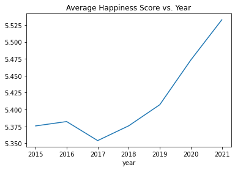

```python
averages = data.groupby('year')['score'].mean()
averages.plot(title = 'Average Happiness Score vs. Year')
```

While it is only a small increase, the line plot of the average happiness scores per year do suggest a positive trend in happiness.

Now, I make scatter plots for some of the other numerical data that I organized earlier. However, since years 2020 and 2021 calculate healthy life expectancy and GDP per capita differently, I have to change the data to match the other years. Since I don't know how to change the data back to the other years' formats, I cannot analyze those for now, but I can analyze perceptions of corruption and freedom to make life choices, which I make scatter plots for.

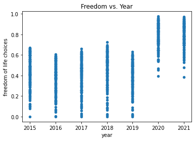

```python
plot2 = data.plot.scatter(x = 'year', y = 'freedom of life choices', title = 'Freedom vs. Year')
```

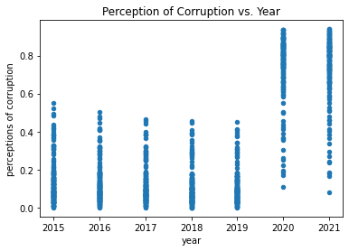

```python
plot3 = data.plot.scatter(x = 'year', y = 'perceptions of corruption', title = 'Perception of Corruption vs. Year')
```

Interestingly, both perceptions of corruption and sense of freedom seem to increase over time, although this is mostly due to a significant spike in both from the years 2020 and 2021. This could be due to a change in how both were measured in those years, but I did not find any evidence to suggest that they were measured differently. Now, we can get the averages and average line plots for these two statistics as well, using similar code to getting the plots for happiness scores.

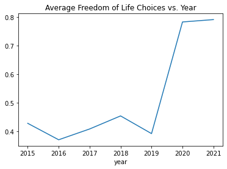

```python
averages2 = data.groupby('year')['freedom of life choices'].mean()
averages2.plot(title = 'Average Freedom of Life Choices vs. Year')
```

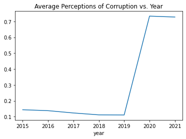

```python
averages3 = data.groupby('year')['perceptions of corruption'].mean()
averages3.plot(title = 'Average Perceptions of Corruption vs. Year')
```

Just as expected, the line plot shows that due to the significant spike from 2020 and 2021, freedom of life choices and perceptions of corruption both seem to increase over time. In the next step of the process, I will test the hypothesis that happiness increased over time.

Part 4: Hypothesis Testing

The main hypothesis that I want to test is that happiness has increased over time, on average. This can easily be tested via fitting a linear regression model for happiness and year, with methods provided by the Scikit-Learn library.

```
[0.02494312]
```

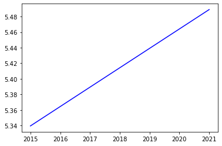

```python
years2 = data.year.array
years3 = np.reshape(years2, (-1, 1))
scores = data['score']
reg = LinearRegression().fit(years3, scores)
prediction = reg.predict(years3)
plt.plot(years2, prediction, color = "blue")
print(reg.coef_)
```

While the slope coefficient of the model seems to show a positive number, a proper hypothesis test is in order to determine if it really is a significant positive linear relationship. Due to how small the slope coefficient is, I can use a null hypothesis of there not being a significant linear relationship(that is, difference between happiness score in 2015 vs. 2021 should be 0). Then, using Scipy(link: https://docs.scipy.org/doc/scipy/index.html) and its ttest_ind method, I perform a two sample t-test, comparing the difference between highest and lowest values on the regression line versus the null difference of 0, with an alpha value of 0.05, meaning that the null hypothesis is rejected with a p value less than 0.05.

```python
from scipy import stats
samp1 = data.loc[data['year'] == 2015, ['score']]
samp2 = data.loc[data['year'] == 2021, ['score']]
t = stats.ttest_ind(samp1, samp2)
print(t.statistic)
print(t.pvalue)
```

```
[-1.23821191]
[0.21658971]
```

From the p value, it is clear that we fail to reject the null hypothesis, meaning that there is actually no significant linear relationship between time and happiness.

To perhaps explain why this is, we can also look at the other two pieces of numerical data that could factor into happiness that I used, those being freedom to make life choices and perceptions of government corruption, and make linear regressions and two sample t-tests for them.

```
[0.06708141]
```

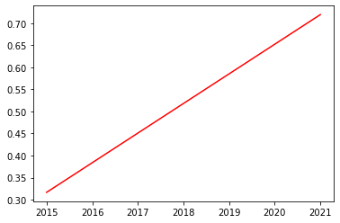

```python
freedoms = data['freedom of life choices']
reg2 = LinearRegression().fit(years3, freedoms)
pred2 = reg2.predict(years3)
plt.plot(years3, pred2, color = "red")
print(reg2.coef_)
```

```python
samp21 = data.loc[data['year'] == 2015, ['freedom of life choices']]
samp22 = data.loc[data['year'] == 2021, ['freedom of life choices']]
t2 = stats.ttest_ind(samp21, samp22)
print(t2.statistic)
print(t2.pvalue)
```

```
[-23.74367405]
[2.66637529e-71]
```

```
[0.10351885]
```

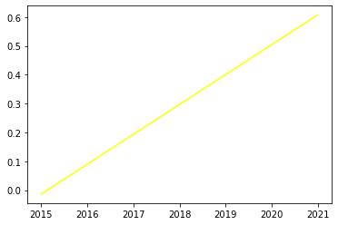

```python
perceptions = data['perceptions of corruption']
reg3 = LinearRegression().fit(years3, perceptions)
pred3 = reg3.predict(years3)
plt.plot(years3, pred3, color = "yellow")
print(reg3.coef_)
```

```python
samp31 = data.loc[data['year'] == 2015, ['perceptions of corruption']]
samp32 = data.loc[data['year'] == 2021, ['perceptions of corruption']]
t3 = stats.ttest_ind(samp31, samp32)
print(t3.statistic)
print(t3.pvalue)
```

```
[-33.71991641]
[6.64775678e-105]
```

Interestingly, perceptions of corruption appear to grow faster than freedom of life choices does. In addition, since the p values for both are very, very small and definitely less than 0.05, we can conclude that perceptions of corruption and freedom of life choices definitely changed over the years, and since corruption's p value was smaller, it changed more. In the last section of the tutorial, I will talk about the implications of this relationship when it comes to happiness over the years.

Part 5: Insights gained from performing analysis

There are obviously many different factors that influence world happiness beyond the two that I was able to cover. Different nations and regions very likely are affected differently by different factors that could affect happiness, and not every one will even follow the same trends of happiness relative to other parameters. For example, there could be a country ruled by a totalitarian dictatorship with high happiness overall despite having no freedom of life choices. However, overall, happiness does appear to be slowly increasing, or at least remaining stable.

When looking at freedom of life choices and perceptions of corruption overall, the fact that perceptions of corruption appear to be increasing faster than freedom may explain why the gain in happiness score per year is lower. Since people believe that the government is getting more corrupt than they are becoming more free to live their lives, happiness may increase more slowly than if they felt more free every year. However, this may not be accurate, as it could just be coincidental. Further research on the topic would certainly be on the other factors listed on the datasets relating to the happiness score, like GDP per capita and social support.

Conclusion

After doing this project and analyzing the dataset, I was able to gain a better understanding of how the world's happiness has been changing. Fortunately, even in spite of the complications of recent times, the happiness of the world does appear to at least be stable, which leaves me very hopeful that people will continue to develop more positive attitudes about the world around them and keep getting happier. In addition, I also gained quite a bit of experience tidying datasets, as the data was very unusual due to how each of the years' datasets had differently-formatted column labels. It also gave me more experience in performing calculations of statistics needed to perform analysis of the data. Overall, it taught me plenty about the data science process and has increased my interest in the field significantly.